# 0328

```r
#####
# set up the environment
#####
# load packages
library(brms)
#library(rethinking)
options(mc.cores = parallel::detectCores())
#rstan_options(auto_write = TRUE)

# adjust the plot region for viewing on the projector in class
options(repr.plot.height=5)
```

```
Loading 'brms' package (version 2.8.0). Useful instructions
can be found by typing help('brms'). A more detailed introduction
to the package is available through vignette('brms_overview').
```

## Panel data: student test scores over time

In this lab, we will be shifting gears to look at panel data. Repeated measurements over the same group of people is a great use case for multilevel models. Because we expect there to be some commonality between the test scores of a particular student over time, we can group indvidual scores at level 1 within students at level 2.

Start by loading a new set of data that is derived from the same Tennessee STAR study we have been using. This time, however, we will look at students across multiple time points: kindergarden through third grade.

As usual, we will subset the data so the model will run faster. The full dataset ha 46,404 observations across 11,601 students. We will look at just 400 of those students.

```r
d <- read.csv("https://mcmahanp.github.io/soci620/data/t_star_student_ts.csv")
dim(d)
length(unique(d$student_id))
# get unique student ids
s <- unique(d$student_id)
# subsample the data
d <- d[d$student_id %in% sample(s,400),]
head(d,20)
dim(d)
```

1. 46404

2. 20

11601

|  | grade | grade_num | student_id | race_ethnicity | born | female | re_white | re_black | re_asian | re_hispanic | re_native_american | re_other | teacher_id | school_id | star | class_type | reading_score | math_score | listening_score | class_size |
| --- | --- | --- | --- | --- | --- | --- | --- | --- | --- | --- | --- | --- | --- | --- | --- | --- | --- | --- | --- | --- |
| 9 | gk | 0 | 10002 | Black | 1979.551 | TRUE | FALSE | TRUE | FALSE | FALSE | FALSE | FALSE | NA | NA | 0 | NA | NA | NA | NA | NA |
| 10 | g1 | 1 | 10002 | Black | 1979.551 | TRUE | FALSE | TRUE | FALSE | FALSE | FALSE | FALSE | NA | NA | 0 | NA | NA | NA | NA | NA |
| 11 | g2 | 2 | 10002 | Black | 1979.551 | TRUE | FALSE | TRUE | FALSE | FALSE | FALSE | FALSE | NA | NA | 0 | NA | NA | NA | NA | NA |
| 12 | g3 | 3 | 10002 | Black | 1979.551 | TRUE | FALSE | TRUE | FALSE | FALSE | FALSE | FALSE | 20549213 | 205492 | 1 | 3 | 577 | 570 | 603 | 23 |
| 449 | gk | 0 | 10112 | White | 1978.485 | FALSE | TRUE | FALSE | FALSE | FALSE | FALSE | FALSE | NA | NA | 0 | NA | NA | NA | NA | NA |
| 450 | g1 | 1 | 10112 | White | 1978.485 | FALSE | TRUE | FALSE | FALSE | FALSE | FALSE | FALSE | NA | NA | 0 | NA | NA | NA | NA | NA |
| 451 | g2 | 2 | 10112 | White | 1978.485 | FALSE | TRUE | FALSE | FALSE | FALSE | FALSE | FALSE | 20549109 | 205491 | 1 | 1 | 627 | 563 | 590 | 14 |
| 452 | g3 | 3 | 10112 | White | 1978.485 | FALSE | TRUE | FALSE | FALSE | FALSE | FALSE | FALSE | NA | NA | 0 | NA | NA | NA | NA | NA |
| 625 | gk | 0 | 10156 | White | 1980.041 | TRUE | TRUE | FALSE | FALSE | FALSE | FALSE | FALSE | NA | NA | 0 | NA | NA | NA | NA | NA |
| 626 | g1 | 1 | 10156 | White | 1980.041 | TRUE | TRUE | FALSE | FALSE | FALSE | FALSE | FALSE | NA | NA | 0 | NA | NA | NA | NA | NA |
| 627 | g2 | 2 | 10156 | White | 1980.041 | TRUE | TRUE | FALSE | FALSE | FALSE | FALSE | FALSE | NA | NA | 0 | NA | NA | NA | NA | NA |
| 628 | g3 | 3 | 10156 | White | 1980.041 | TRUE | TRUE | FALSE | FALSE | FALSE | FALSE | FALSE | 26293716 | 262937 | 1 | 2 | 602 | 634 | 617 | 26 |
| 661 | gk | 0 | 10165 | White | 1979.145 | FALSE | TRUE | FALSE | FALSE | FALSE | FALSE | FALSE | NA | NA | 0 | NA | NA | NA | NA | NA |
| 662 | g1 | 1 | 10165 | White | 1979.145 | FALSE | TRUE | FALSE | FALSE | FALSE | FALSE | FALSE | NA | NA | 0 | NA | NA | NA | NA | NA |
| 663 | g2 | 2 | 10165 | White | 1979.145 | FALSE | TRUE | FALSE | FALSE | FALSE | FALSE | FALSE | 18937810 | 189378 | 1 | 3 | 549 | 626 | 593 | 25 |
| 664 | g3 | 3 | 10165 | White | 1979.145 | FALSE | TRUE | FALSE | FALSE | FALSE | FALSE | FALSE | NA | NA | 0 | NA | NA | NA | NA | NA |
| 765 | gk | 0 | 10191 | White | 1980.221 | TRUE | TRUE | FALSE | FALSE | FALSE | FALSE | FALSE | NA | NA | 0 | NA | NA | NA | NA | NA |
| 766 | g1 | 1 | 10191 | White | 1980.221 | TRUE | TRUE | FALSE | FALSE | FALSE | FALSE | FALSE | 24483107 | 244831 | 1 | 3 | 558 | 502 | 531 | 24 |
| 767 | g2 | 2 | 10191 | White | 1980.221 | TRUE | TRUE | FALSE | FALSE | FALSE | FALSE | FALSE | 24483109 | 244831 | 1 | 3 | 573 | 536 | 556 | 25 |
| 768 | g3 | 3 | 10191 | White | 1980.221 | TRUE | TRUE | FALSE | FALSE | FALSE | FALSE | FALSE | 24483114 | 244831 | 1 | 3 | 587 | 576 | 577 | 21 |

1. 1600

2. 20

Because of the structure of the data, many observations for test scores are missing (NA). Test scores were only collected for students in the study classrooms, and students move in and out of the study over the four years of data collection. Moreover, many of the students are included in the data as comparison cases, and have no test score measurements at all.

We can visualize this by picking 30 random students and plotting their test scores over time. Many of the lines are incomplete, and many of the students do not appear in the figure at all.

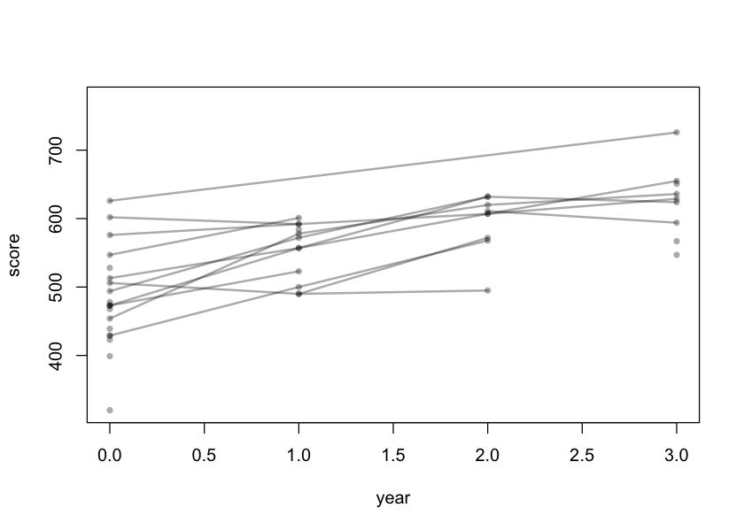

```r
plot(NA,xlim=c(0,3),ylim=range(d$math_score,na.rm=TRUE),xlab='year',ylab='score')
for(sid in sample(unique(d$student_id),30)){ # loop over 30 random students
    # make a new data frame just for this student:
    dd <- na.omit(d[d$student_id==sid,])
    lines(dd$grade_num,dd$math_score,col='#00000055',lwd=2)
    # overlay points for more clarity
    points(dd$grade_num,dd$math_score,col='#00000055',pch=16,cex=.8)
}
```

### Random-intercept

A simple model of inter-student variation allows the intercept to vary from student to student. Here, we will predict student test scores using just class size:

$$\begin{align} S_{ti} &\sim \mathrm{Norm}(\mu_{ti},\sigma)\\ \mu_{ti} &= \beta_{0i} + \beta_{1}CSize_{ti} \\ \beta_{0i} &= \gamma_{00} + \eta_{0i}\\ \\ \eta_{0i} &\sim \mathrm{Norm}(0,\phi_0)\\ \\ \gamma_{00} &\sim \mathrm{Norm}(500,100)\\ \beta_{1} &\sim \mathrm{Norm}(0,30)\\ \sigma &\sim \mathrm{HalfCauchy}(0,50)\\ \phi_0 &\sim \mathrm{HalfCauchy}(0,50)\\ \end{align}$$

```r
# center class size
d$class_size_c <- d$class_size-20
```

```r
m1 <- math_score ~ class_size_c + (1 | student_id)
t0 <- Sys.time()
fit1 <- brm(
    m1,data=d,
    prior=c(
        set_prior("normal(500,100)",class="Intercept"), # gamma_00
        set_prior("normal(0,30)",class='b'), # default prior for coefficients
        set_prior("cauchy(0,50)",class='sigma'), # sigma
        set_prior("cauchy(0,50)",class='sd') # phi_0
    ),
    cores=8,chains=8,iter=1500,warmup=1000,
    control=list(adapt_delta=.99)
)
t1 <- Sys.time()
t1-t0
```

```
Time difference of 55.15727 secs
```

```r
summary(fit1,prob=0.9)
```

```
 Family: gaussian
  Links: mu = identity; sigma = identity
Formula: math_score ~ class_size_c + (1 | student_id)
   Data: d (Number of observations: 846)
Samples: 8 chains, each with iter = 1500; warmup = 1000; thin = 1;
         total post-warmup samples = 4000

Group-Level Effects:
~student_id (Number of levels: 373)
              Estimate Est.Error l-90% CI u-90% CI Eff.Sample Rhat
sd(Intercept)    35.20      3.74    29.14    41.41        915 1.01

Population-Level Effects:
             Estimate Est.Error l-90% CI u-90% CI Eff.Sample Rhat
Intercept      544.94      2.89   540.22   549.76       3652 1.00
class_size_c     1.43      0.65     0.38     2.49       4394 1.00

Family Specific Parameters:
      Estimate Est.Error l-90% CI u-90% CI Eff.Sample Rhat
sigma    58.15      1.95    54.97    61.40       1707 1.00

Samples were drawn using sampling(NUTS). For each parameter, Eff.Sample
is a crude measure of effective sample size, and Rhat is the potential
scale reduction factor on split chains (at convergence, Rhat = 1).
```

### Temporal modelling

While the random-intercept model takes into account clustered variation for each student, it does not allow for any kinds of structured change over time, either within or across students. To do this, we expand the model by adding a predictor for grade number. The data has two variables measuring grade: `grade` is one of `gk`, `g1`, `g2`, or `g3`, while `grade_num` is an integer with values zero through three. We will use `grade_num` to model a linear temporal trend in student scores. Moreover, we will allow this linear trend to vary according to student. Note that we do *not* have inter-student variation on the coefficient for class size—there is no need to vary all of yoru slopes randomly if you do not have a reason to do so.

```r
m2 <- math_score ~ grade_num + class_size_c + (1 + grade_num | student_id)
t0 <- Sys.time()
fit2 <- brm(
    m2,data=d,
    prior=c(
        set_prior("normal(500,100)",class="Intercept"), # gamma_00
        set_prior("normal(0,30)",class='b'), # default prior for coefficients
        set_prior("cauchy(0,50)",class='sigma'), # sigma
        set_prior("cauchy(0,50)",class='sd'), # phi_0, phi_1
        set_prior("lkj(2)",class='cor') # phi_0
    ),
    cores=8,chains=8,iter=1500,warmup=1000,
    control=list(adapt_delta=.99)
)
t1 <- Sys.time()
t1-t0
```

```
Time difference of 1.566119 mins
```

```r
summary(fit2,prob=.9)
```

```
 Family: gaussian
  Links: mu = identity; sigma = identity
Formula: math_score ~ grade_num + class_size_c + (1 + grade_num | student_id)
   Data: d (Number of observations: 846)
Samples: 8 chains, each with iter = 1500; warmup = 1000; thin = 1;
         total post-warmup samples = 4000

Group-Level Effects:
~student_id (Number of levels: 373)
                         Estimate Est.Error l-90% CI u-90% CI Eff.Sample Rhat
sd(Intercept)               42.68      2.29    39.08    46.53        917 1.00
sd(grade_num)                8.67      1.55     6.06    11.13        363 1.02
cor(Intercept,grade_num)    -0.50      0.10    -0.64    -0.32       2577 1.00

Population-Level Effects:
             Estimate Est.Error l-90% CI u-90% CI Eff.Sample Rhat
Intercept      482.82      2.79   478.29   487.41       1250 1.00
grade_num       44.05      1.02    42.35    45.74       3094 1.00
class_size_c    -0.46      0.38    -1.09     0.15       2284 1.00

Family Specific Parameters:
      Estimate Est.Error l-90% CI u-90% CI Eff.Sample Rhat
sigma    22.84      0.94    21.37    24.45        511 1.01

Samples were drawn using sampling(NUTS). For each parameter, Eff.Sample
is a crude measure of effective sample size, and Rhat is the potential
scale reduction factor on split chains (at convergence, Rhat = 1).
```

Notice that adding this time-dependency actually flips the sign of the coefficient on class size (and would do so 'significantly' if we used the full data set). Also, there is a strong negative correlation between the random effect on grade number and the random intercept. This means that students that have a higher average score will tend to have a lower slope associated with time.

We can compare the WAIC for the two models to see if the fit is better after taking time into account.

```r
waic(fit1,fit2)
```

```
Output of model 'fit1':

Computed from 4000 by 846 log-likelihood matrix

          Estimate   SE
elpd_waic  -4721.5 17.6
p_waic       145.7  5.9
waic        9443.1 35.1

Output of model 'fit2':

Computed from 4000 by 846 log-likelihood matrix

          Estimate   SE
elpd_waic  -4028.4 19.1
p_waic       283.9 10.5
waic        8056.8 38.3

Model comparisons:
     elpd_diff se_diff
fit2    0.0       0.0
fit1 -693.1      21.4
```

It can be useful to plot the predicted temporal trend for individual students. To do this with `brms`, you can extract the "fixed" and "random" effects.

`fixef()` returns a matrix with one row for each coefficient and four columns listing the mean, standard error, and percentile interval for each of them.

`ranef()` returns something more complicated: a list of group-level effects for each of the grouping variables we used. Since we only used one (`student_id`) it is a list of length 1. Each element of that list (in our case just the one element) is a 3-dimensional array listing the mean, standard error, and percentile range for each student and for each coefficient.

```r
re2 <- ranef(fit2)
fe2 <- fixef(fit2)
fe2
```

|  | Estimate | Est.Error | Q2.5 | Q97.5 |
| --- | --- | --- | --- | --- |
| Intercept | 482.8240330 | 2.7931220 | 477.33139 | 488.2888210 |
| grade_num | 44.0527535 | 1.0244212 | 42.02755 | 46.0185254 |
| class_size_c | -0.4601714 | 0.3776472 | -1.23055 | 0.2942208 |

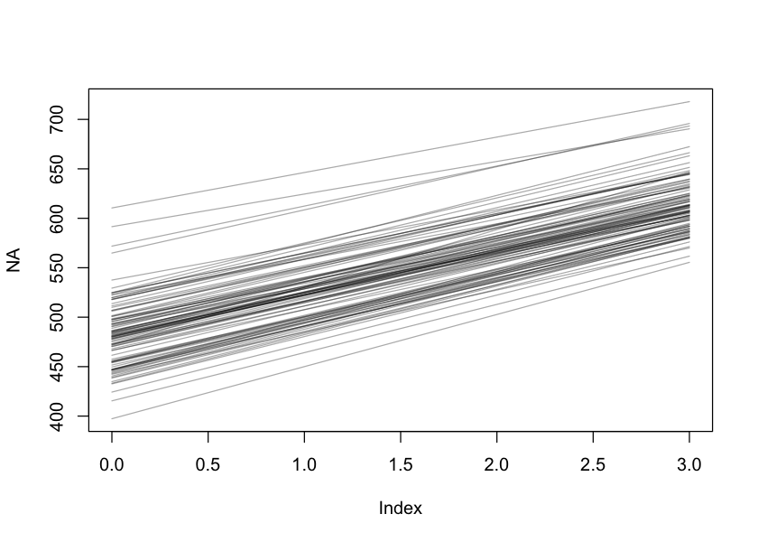

```r
# get the intercept for each student (random plus fixed effect)
a <- re2[[1]][,"Estimate","Intercept"] + fe2["Intercept","Estimate"]
# get the slope for each student (random plus fixed effect)
b <- re2[[1]][,"Estimate","grade_num"] + fe2["grade_num","Estimate"]

# take a sample of 100 students
s <- sample(length(a),100)
# figure out a good vertical range
ylim <- range(a[s],(a+3*(b))[s])
# plot the individual lines
plot(NA,xlim=c(0,3),ylim=ylim)
for(i in s){
    lines(c(0,3),c(a[i],a[i] + 3*b[i]),col='#00000055')
}
```